# Ubiqum - week 6 || Market basket analysis

Blackwell data department - Analyst: Toine

# Executive summary

This memo explores the data provided by Electronidex in order to investigate whether it is an attractive acquisition target for Blackwell. Below, the most important findings and recommendations are listed:

### Observations from data

- The target company is strong in selling desktops and laptops with Apple being their most popular brand (the iMac is sold in ~25% of all transactions). Regardless of whether we acquire the target company, it is interesting to investigate Apple products further if we don’t carry them yet (I’m only aware of the iPhone being sold in our stores).
- Electronidex has two distinct types of buyers. One group buys multiple desktops and laptops simultanously, while the other group buys only one type of machine. Unfortunately, it is impossible to see whether the latter group buys only one or many of these same type of machine. Assuming it’s only one machine, this group is likely to consist of private individuals.
- The other group buys multiple types of machines at the same time. Further analysis shows that they quite often also buy MS Office Home and Student edition. As this version does not provide an adequate licence for companies, it is likely that the group exists of academic organisations, schools and/or NGOs.
- Monitors are the most important accessoire to be sold with laptops and desktops. Especially the SonicView monitor seems to be doing really well.
- It is noteworthy that despite the iMac being the best selling product, that the Apple accessoires don’t seem to do very well. This is an interesting opportunity to explore further.

### Data quality recommendations

- The amount of data covers only one month of transactions. Therefore, it is impossible to correct for seasonality. Moreover, the target company may have boosted the numbers (e.g. by having aggressive promotions, by delaying sales to clients to this month, etc.). We should request addition data to be made available to us.
- The data does not contains actual sales volume figures. Hence, it is hard to compare Electronidex’s sales figures to ours. However, it is clear that the most commonly sold products are both desktops and laptops, categories in which we are not strong.

### Conclusions

Based on the provided data, and if the findings above are confirmed by additional data, the acquisition of Electronidex could be beneficial to us.

- Electronidex has an established online store. Since we have only been selling online recently, this acquisition could help us with a good market position in one go.
- There is reason for concern that we have only been provided with one month of data. It should be investigated whether this is due to internal problems at the target company.
- If further due diligence confirms that the month for which data has been provided is not unusual for the target company, we would acquire a monthly transaction volume of 9,800. Although our sales department did not provide a time window in which the historical transactions were recorded, it does seem a significant amount given the transactions that have been analysed before.
- The portfolio of the target company is complementary to ours, as it’s best selling products (laptops and desktops) are mediocre performers in our stores.

# Methodology

## Initial data exploration

Initial exploration of the data:

```
## The total amount of observations is: 9835
```

```
## The average number of items in a transaction is: 4.382715
```

```
## transactions as itemMatrix in sparse format with
##  9835 rows (elements/itemsets/transactions) and
##  125 columns (items) and a density of 0.03506172
##
## most frequent items:
##                     iMac                HP Laptop CYBERPOWER Gamer Desktop
##                     2519                     1909                     1809
##            Apple Earpods        Apple MacBook Air                  (Other)
##                     1715                     1530                    33622
##
## element (itemset/transaction) length distribution:
## sizes
##    0    1    2    3    4    5    6    7    8    9   10   11   12   13   14
##    2 2163 1647 1294 1021  856  646  540  439  353  247  171  119   77   72
##   15   16   17   18   19   20   21   22   23   25   26   27   29   30
##   56   41   26   20   10   10   10    5    3    1    1    3    1    1
##
##    Min. 1st Qu.  Median    Mean 3rd Qu.    Max.
##   0.000   2.000   3.000   4.383   6.000  30.000
##
## includes extended item information - examples:
##                             labels
## 1 1TB Portable External Hard Drive
## 2 2TB Portable External Hard Drive
## 3                   3-Button Mouse
```

Next, the top selling products of the target company:

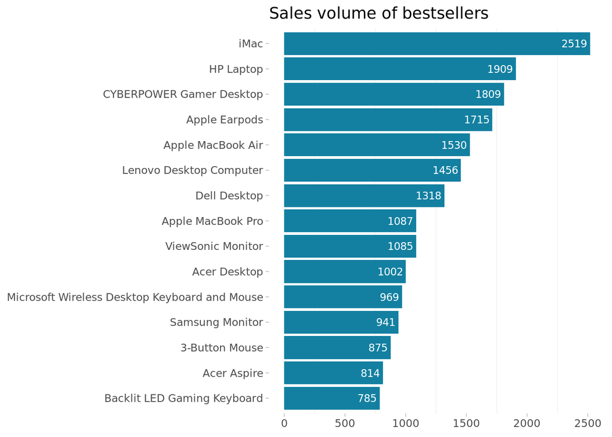

It is also interesting to see what people buy when only one item is bought in a transaction. The Apple Macbook Air is the most popular product in this case, but also notice that the amount of sales per product are just a small part of the total volume. In other words, there are a lot of transactions in which many desktops and laptops are being bought simultaneously.

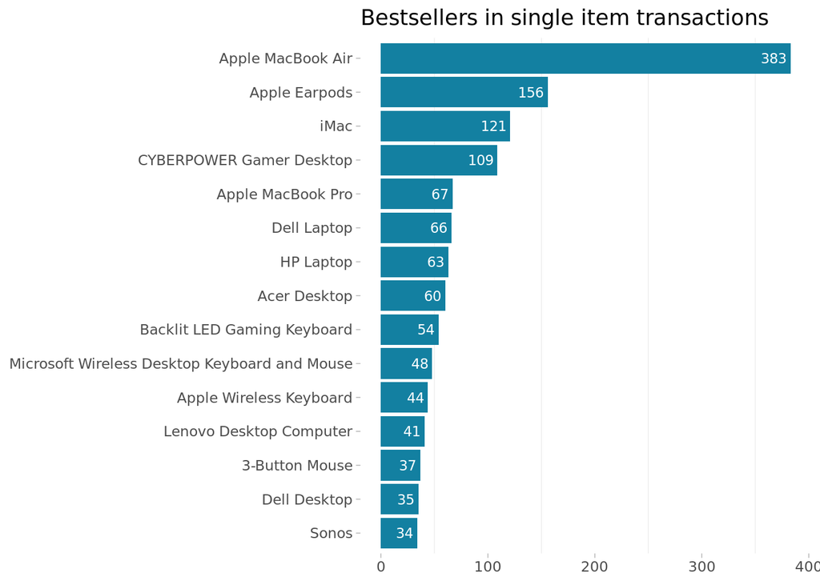

## Alteration of data

*Type of clients* As noted above, it is pretty clear that the client group is not homogenous. In a consumer electronics store, one would except transactions that include one type of desktop or laptop, and some complementary items (such as a keyboard or printer). In addition, there are transactions for only complementary items. In this case, a large amount of transactions include multiple desktops and laptops, indicating that the buyer might be a organisation instead of a private individual.

To split the data for these groups, separate datasets have been created using a ‘organisation’ flag. If more than one type of desktop or laptop was purchased, the transaction was flagged as ‘organisation’.

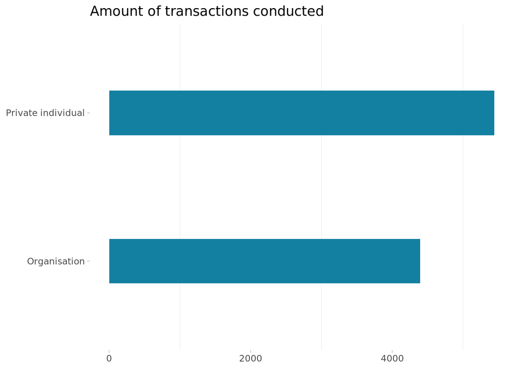

*Product categories* In addition to analysing on a product level, it is also useful to look at a product type level. In this way, relations between for example computers and accessoirces become more clear.

The chart below shows that the target company is strong in the Desktop, and Laptop divisions. These are both categories that are weak performers within our company. If compared to the Blackwell product types that do well (see chart below), it is really interesting to see that our bestseller, game consoles, are not even being offered by Electronidex.

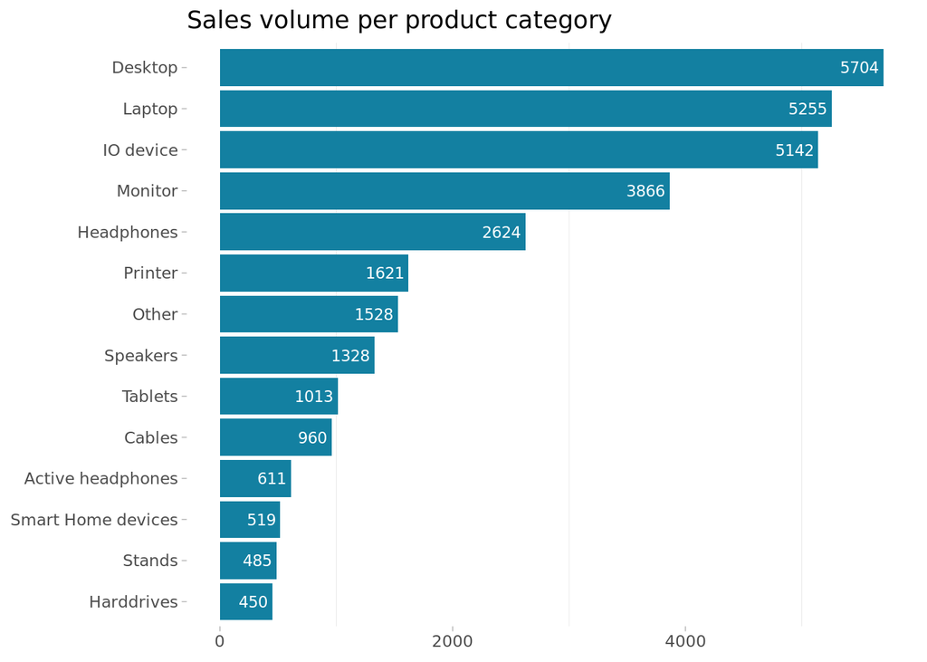

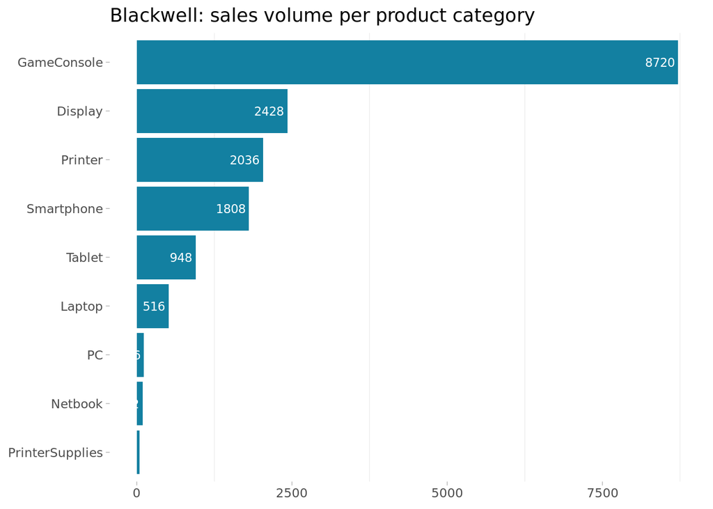

## Rule creation

Next, a market basket analysis is used in order to gain insight in which products are generally sold together. This might provide some clues as to which products can be recommended together, and whether there is potential for improvement.

### Complete dataset

It shows that a lot of desktops and computers are being bought together. Hence, the reason why we split the dataset for organisations and private individuals earlier. Furthermore, it can be observed that the ViewSOnic Monitor is an important accessoire.

|  | lhs | Var.3 | rhs | support | confidence | lift | count |
| --- | --- | --- | --- | --- | --- | --- | --- |
| [1] | {Acer Aspire,HP Laptop} | =&gt; | {ViewSonic Monitor} | 0.0107778342653787 | 0.370629370629371 | 3.359575907963 | 106 |
| [2] | {Acer Aspire,ViewSonic Monitor} | =&gt; | {HP Laptop} | 0.0107778342653787 | 0.602272727272727 | 3.10285608838516 | 106 |
| [3] | {Dell Desktop,HP Laptop} | =&gt; | {ViewSonic Monitor} | 0.0152516522623284 | 0.339366515837104 | 3.07619325645891 | 150 |
| [4] | {ASUS Chromebook} | =&gt; | {ViewSonic Monitor} | 0.0174885612608033 | 0.333333333333333 | 3.02150537634409 | 172 |
| [5] | {Acer Desktop,HP Laptop} | =&gt; | {Dell Desktop} | 0.0124046771733604 | 0.397394136807818 | 2.96538037595211 | 122 |

Next, categories of products usually bought together are assessed. As we know that desktop and laptops are usually the main item in a purchase, we make sure that these are only found in the left hand side of the rule equation.

|  | lhs | Var.3 | rhs | support | confidence | lift | count |
| --- | --- | --- | --- | --- | --- | --- | --- |
| [1] | {Desktop,Laptop} | =&gt; | {Monitor} | 0.182409761057448 | 0.568801521876982 | 1.44701577021731 | 1794 |
| [2] | {Desktop,Laptop} | =&gt; | {IO device} | 0.212811387900356 | 0.663601775523145 | 1.2692577717367 | 2093 |
| [3] | {Desktop,Laptop} | =&gt; | {Headphones} | 0.104829689883071 | 0.326886493341788 | 1.22520147180506 | 1031 |
| [4] | {Desktop} | =&gt; | {Monitor} | 0.278596847991866 | 0.480364656381487 | 1.22203476345368 | 2740 |
| [5] | {Laptop} | =&gt; | {Monitor} | 0.240366039654296 | 0.449857278782112 | 1.14442481552563 | 2364 |

Given that laptops and desktops are clearly the main items in a transactions, let’s see what people tend to buy together with those items. From the rules below, sorted by frequency (count), it becomes clear that the following products are sold most with a computer:

1. Apple Earpods
2. Viewsonic monitor
3. Samsung monitor
4. I/O-devices (mouse, keyboard)
5. MS Office Home/Student

It should be noted that Apple earpods are a popular item by itself as well. Hence, this is an important item to carry, but not necessarily to target is a accessoire for a computer. This is different with the Viewsonic monitor, which is selling much more with a computer than in standalone transactions. The same is true for other monitors (i.e. the one from HP), and MS Office.

[interactive table not shown]

### Organisations vs. private individuals

If we repeat that analysis for organisation only, only rules with a really low confidence and/or lift are found. Hence, the results don’t give us any additional information on what accessoires are favored by organisations.

[interactive table not shown]

For private individuals, it becomes clear that about 5% of the individuals that buy a desktop also buys a monitor. That ratio might be interesting to improve via promotions and other marketing efforts.

|  | lhs | Var.3 | rhs | support | confidence | lift | count |
| --- | --- | --- | --- | --- | --- | --- | --- |
| [1] | {Desktop} | =&gt; | {ASUS 2 Monitor} | 0.0152573529411765 | 0.0475372279495991 | 1.41312852484054 | 83 |
| [2] | {Desktop} | =&gt; | {Slim 2TB Portable External Hard Drive} | 0.0102941176470588 | 0.0320733104238259 | 1.40708716698075 | 56 |
| [3] | {Desktop} | =&gt; | {Apple Magic Keyboard} | 0.0176470588235294 | 0.0549828178694158 | 1.38475245004455 | 96 |
| [4] | {Desktop} | =&gt; | {Acer Monitor} | 0.0176470588235294 | 0.0549828178694158 | 1.37204829912671 | 96 |
| [5] | {Desktop} | =&gt; | {HP Monitor} | 0.0183823529411765 | 0.0572737686139748 | 1.34297112612079 | 100 |

### Bestsellers

Lastly, it is interesting to look what products sell well together with the target companies’ bestsellers: the iMac and HP Laptop.

For the iMac, the mostly sold accesoires are the Viewsonic Monitor, the Apple earpods, and the 3-button mouse. However, the Apple earpods sell so much without iMacs as well, that there seems to be no relation with the iMac.

|  | lhs | Var.3 | rhs | support | confidence | lift | count |
| --- | --- | --- | --- | --- | --- | --- | --- |
| [1] | {iMac} | =&gt; | {ASUS Monitor} | 0.0276563294356889 | 0.107979356887654 | 1.94858160548638 | 272 |
| [2] | {iMac} | =&gt; | {ASUS 2 Monitor} | 0.0280630401626843 | 0.10956728860659 | 1.90051901842295 | 276 |
| [3] | {iMac} | =&gt; | {Microsoft Office Home and Student 2016} | 0.0310116929334011 | 0.121079793568877 | 1.82082533600902 | 305 |
| [4] | {iMac} | =&gt; | {Apple Magic Keyboard} | 0.0323335027961362 | 0.126240571655419 | 1.76110074075325 | 318 |
| [5] | {iMac} | =&gt; | {ViewSonic Monitor} | 0.0494153533299441 | 0.192933703850734 | 1.74885067038892 | 486 |
| [6] | {iMac} | =&gt; | {Eluktronics Pro Gaming Laptop} | 0.0157600406710727 | 0.0615323541087733 | 1.72413305601079 | 155 |
| [7] | {iMac} | =&gt; | {HDMI Cable 6ft} | 0.0114895780376207 | 0.0448590710599444 | 1.72339439013497 | 113 |
| [8] | {iMac} | =&gt; | {Panasonic In-Ear Headphone} | 0.0107778342653787 | 0.0420801905518063 | 1.68921907786537 | 106 |
| [9] | {iMac} | =&gt; | {Epson Printer} | 0.0204372140315201 | 0.0797935688765383 | 1.65913266363796 | 201 |
| [10] | {iMac} | =&gt; | {Intel Desktop} | 0.0164717844433147 | 0.0643112346169115 | 1.62179741655724 | 162 |

Buyers of an HP Laptop (which interesingly is often sold together with a iMac) is often sold together with the ViewSonic MOnitor, computer games, and the Apple magic keyboard.

|  | lhs | Var.3 | rhs | support | confidence | lift | count |
| --- | --- | --- | --- | --- | --- | --- | --- |
| [1] | {HP Laptop} | =&gt; | {ViewSonic Monitor} | 0.0479918657854601 | 0.247249869041383 | 2.24120042582673 | 472 |
| [2] | {HP Laptop} | =&gt; | {Computer Game} | 0.0179969496695475 | 0.0927187008905186 | 2.20796228391828 | 177 |
| [3] | {HP Laptop} | =&gt; | {HP Wireless Mouse} | 0.0178952719877987 | 0.0921948664222106 | 2.11854325061318 | 176 |
| [4] | {HP Laptop} | =&gt; | {Eluktronics Pro Gaming Laptop} | 0.0144382308083376 | 0.0743844944997381 | 2.08424929744993 | 142 |
| [5] | {HP Laptop} | =&gt; | {Apple Magic Keyboard} | 0.0288764616166751 | 0.148768988999476 | 2.07538015150333 | 284 |

# Appendix for Ubiqum mentors: code

```r
## Load libraries =================================
library(arulesViz)
library(arules)
library(tidyverse)
library(magrittr)

## Prepare clusters =================================
#cl <- makeCluster(3)
#registerDoParallel(cl)
## Import dataset =================================
elecTransactions <- read.transactions('../input/ElectronidexTransactions2017.csv', sep = ',', rm.duplicates = F, format = "basket")
## Explore dataset =================================
cat("The total amount of observations is:", length(elecTransactions)) #provides total amount of observations

#Find out average number of different items in transaction
cat("The average number of items in a transaction is:", mean(size(elecTransactions)))

#size(elecTransactions) # provides vector with number of items per observation
#LIST(elecTransactions) #Lists the transactions by conversion (LIST must be capitalized)
#itemLabels(elecTransactions) # To see the item labels
summary(elecTransactions)
## Visualize dataset ===============================
#Visualization of most commonly bought items
# itemFrequencyPlot(elecTransactions, topN = "15",
#                   type="absolute",
#                   horiz = T,
#                   main="Absolute Item Frequency Plot"
#                   )

#ggplot version
elecTransactions %>%
  itemFrequency(type = "absolute") %>%
  sort(decreasing = T) %>%
  head(n = 15) %>%
  as_tibble(pkgconfig::set_config("tibble::rownames" = "ProductType")) %>%
  ggplot(aes(x = reorder(ProductType, value), y = value)) +
    geom_bar(stat = "identity") +
    geom_col(fill = "#1380A1") +
    coord_flip() +
    theme_light() +
    theme(
      axis.title = element_text(size = 18),
      axis.title.x=element_blank(),
      axis.title.y=element_blank(),
      panel.border=element_blank(),
      panel.grid.major=element_blank()
    ) +
  labs(title = "Sales volume of bestsellers") +
  geom_label(aes(x = ProductType, y = value, label = round(value, 0)),
             hjust = 1,
             vjust = 0.5,
             colour = "white",
             fill = NA,
             label.size = NA,
             family="Helvetica",
             size = 3)

#Find out most sold items in transactions with only one item
oneItemSales <- subset(elecTransactions, size(elecTransactions) == 1)
# itemFrequencyPlot(oneItemSales, topN = "15",
#                   type="absolute",
#                   horiz = T,
#                   main="Absolute Item Frequency Plot"
#                   )
#ggplot version
oneItemSales %>%
  itemFrequency(type = "absolute") %>%
  sort(decreasing = T) %>%
  head(n = 15) %>%
  as_tibble(pkgconfig::set_config("tibble::rownames" = "ProductType")) %>%
  ggplot(aes(x = reorder(ProductType, value), y = value)) +
    geom_bar(stat = "identity") +
    geom_col(fill = "#1380A1") +
    coord_flip() +
    theme_light() +
    theme(
      axis.title = element_text(size = 18),
      axis.title.x=element_blank(),
      axis.title.y=element_blank(),
      panel.border=element_blank(),
      panel.grid.major=element_blank()
    ) +
  labs(title = "Bestsellers in single item transactions") +
  geom_label(aes(x = ProductType, y = value, label = round(value, 0)),
             hjust = 1,
             vjust = 0.5,
             colour = "white",
             fill = NA,
             label.size = NA,
             family="Helvetica",
             size = 3)

#Clean-up
remove(oneItemSales)

# #Visualization of sample of transactions
# image(sample(elecTransactions, 200))
df <- readr::read_csv('../input/ElectronidexTransactions2017.csv', col_names = F, trim_ws = T)

#Initialize category variable
corporation <- logical(dim(df)[1])

computers <- c(
  "LG Touchscreen Laptop",
  "Acer Aspire",
  "HP Laptop",
  "ASUS Chromebook",
  "Apple MacBook Pro",
  "Apple MacBook Air",
  "Dell Laptop",
  "Eluktronics Pro Gaming Laptop",
  "Alienware Laptop",
  "HP Notebook Touchscreen Laptop PC",
  "Lenovo Desktop Computer",
  "iMac",
  "HP Desktop",
  "ASUS Desktop",
  "Dell Desktop",
  "Intel Desktop",
  "Acer Desktop",
  "CYBERPOWER Gamer Desktop"
)

#Run in a loop over all transactions, and flag corporation TRUE if a transaction has >1 computer
for (i in 1:length(corporation)) {
  compcount <- 0
  for (j in 1:length(df[i,])) {
    if (df[i,j] %in% computers) {
      compcount <- compcount + 1
      if (compcount > 1) {
        corporation[i] <- TRUE; break
      }
    }
  }
}

#Clean up df
remove(df, i, j, compcount, computers)

#Plot division between corp and private

division <- tribble(~whatever, ~buyertype, ~amount,
                    "whatever", "Organisation", length(corporation[corporation == TRUE]),
                    "whatever",  "Private individual", length(corporation[corporation == FALSE]))

division %>%
  ggplot(aes(x = buyertype, y = amount)) +
    geom_col(fill = "#1380A1", width = 0.3) +
    coord_flip() +
    theme_light() +
    theme(
      axis.title = element_text(size = 18),
      axis.title.x=element_blank(),
      axis.title.y=element_blank(),
      panel.border=element_blank(),
      panel.grid.major=element_blank()
    ) +
  labs(title = "Amount of transactions conducted")
  geom_label(aes(x = buyertype, y = amount, label = round(amount, 0)),
             hjust = 1,
             vjust = 0.5,
             colour = "white",
             fill = NA,
             label.size = NA,
             family="Helvetica",
             size = 3)

#Code to screen for MS office in transaction
# if (elecTransactions[i]@data[97]) {
#   category[i] <- "PrivateIndividual"
# }
## Create new dataset with categories instead of products ====================================

#Separate function for desktops and laptops. Now no longer needed, but was used earlier multiple times.

DeskLap <- function(df) {
  laptops <- c(
    "LG Touchscreen Laptop",
    "Acer Aspire",
    "HP Laptop",
    "ASUS Chromebook",
    "Apple MacBook Pro",
    "Apple MacBook Air",
    "Dell Laptop",
    "Eluktronics Pro Gaming Laptop",
    "Alienware Laptop",
    "HP Notebook Touchscreen Laptop PC"
  )
  desktops <- c(
    "Lenovo Desktop Computer",
    "iMac",
    "HP Desktop",
    "ASUS Desktop",
    "Dell Desktop",
    "Intel Desktop",
    "Acer Desktop",
    "CYBERPOWER Gamer Desktop",
    "Dell 2 Desktop"
    )
```

```r
  for (i in seq_along(laptops)){
    df[df == laptops[i]] <- "Laptop"
  }

  for (i in seq_along(desktops)){
    df[df == desktops[i]] <- "Desktop"
  }
  df
}

#The rest is done without a function:
cateTrans <- readr::read_csv('../input/ElectronidexTransactions2017.csv', col_names = F, trim_ws = T)

monitors <- c(
  "Acer Monitor",
  "LG Monitor",
  "ASUS Monitor",
  "ASUS 2 Monitor",
  "Dell Monitor",
  "Samsung Monitor",
  "Sceptre Monitor",
  "ViewSonic Monitor",
  "AOC Monitor",
  "HP Monitor"
  )
iodevices <- c(
  "3-Button Mouse",
  "Logitech Wireless Mouse",
  "Microsoft Basic Optical Mouse",
  "Logitech 3-button Mouse",
  "Redragon Gaming Mouse",
  "HP Wireless Mouse",
  "Generic Black 3-Button",
  "Wireless Portable Mouse",
  "Gaming Mouse Professional",
  "Slim Wireless Mouse",
  "HP USB Keyboard",
  "Logitech Wireless Keyboard",
  "Rii LED Keyboard",
  "Logitech Keyboard",
  "Backlit LED Gaming Keyboard",
  "Dell Wired Keyboard",
  "Apple Wired Keyboard",
  "Apple Wireless Keyboard",
  "Apple Magic Keyboard",
  "Logitech MK550 Wireless Wave Keyboard and Mouse Combo",
  "Logitech Desktop MK120 Mouse and keyboard Combo",
  "Logitech MK270 Wireless Keyboard and Mouse Combo",
  "Dell KM117 Wireless Keyboard & Mouse",
  "EagleTec Wireless Combo Keyboard and Mouse",
  "Microsoft Wireless Comfort Keyboard and Mouse",
  "Microsoft Wireless Desktop Keyboard and Mouse",
  "Rii LED Gaming Keyboard & Mouse Combo",
  "Logitech MK360 Wireless Keyboard and Mouse Combo"
)

headphones <- c(
  "Zombie Gaming Headset",
  "Logitech ClearChat Headset",
  "Panasonic On-Ear Stereo Headphones",
  "PC Gaming Headset",
  "Kensington Headphones",
  "Logitech Stereo Headset",
  "Koss Home Headphones",
  "Microsoft Headset",
  "Ailihen Stereo Headphones",
  "XIBERIA Gaming Headset",
  "Active Headphones",
  "Apple Earpods",
  "Monster Beats By Dr Dre"
)
activeheadphones <- c(
  "Apple Earpods",
  "Monster Beats by Dre",
  "Otium Wireless Sports Bluetooth Headphone",
  "Panasonic In-Ear Headphone",
  "APIE Bluetooth Headphone",
  "Philips Flexible Earhook Headphone"
)
cables <- c(
  "HDMI Cable 6ft",
  "Ethernet Cable",
  "Etekcity Power Extension Cord Cable",
  "Audio Cable",
  "VGA Monitor Cable",
  "iPhone Charger Cable",
  "HDMI Adapter",
  "USB Cable",
  "Samsung Charging Cable"
)
other <- c(
  "Microsoft Office Home and Student 2016",
  "Computer Game",
  "Belkin Mouse Pad",
  "Large Mouse Pad"
)
speakers <- c(
  "Cambridge Bluetooth Speaker",
  "JBL Splashproof Portable Bluetooth Speaker",
  "DOSS Touch Wireless Bluetooth",
  "Logitech Multimedia Speakers",
  "Rokono Mini Speaker",
  "Cyber Acoustics",
  "Bose Companion Speakers",
  "Mackie CR Speakers",
  "Sonos"
)
printer <- c(
  "Epson Printer",
  "HP Wireless Printer",
  "Canon Office Printer",
  "Brother Printer",
  "DYMO Label Manker",
  "Epson Black Ink",
  "HP Black & Tri-color Ink",
  "Canon Ink",
  "Brother Printer Toner",
  "DYMO Labeling Tape"
)
stands <- c(
  "Halter Acrylic Monitor Stand",
  "Height-Adjustable Standing Desk",
  "Multi Media Stand",
  "Halter Mesh Metal Monitor Stand",
  "Full Motion Monitor Mount"
)
tablets <- c(
  "iPad",
  "iPad Pro",
  "Fire HD Tablet",
  "Samsung Galaxy Tablet",
  "Kindle"
)
harddrives <- c(
  "1TB Portable External Hard Drive",
  "2TB Portable External Hard Drive",
  "5TB Desktop Hard Drive",
  "Slim 2TB Portable External Hard Drive",
  "3TB Portable External Hard Drive"
)
smarthome <- c(
  "Apple TV",
  "Google Home",
  "Smart Light Bulb",
  "Fire TV Stick",
  "Roku Express"
)

cateTrans %<>% DeskLap()

##Create datasets with only laptops and desktops transformed
#Write data frame to HDD
readr::write_csv(cateTrans, '../input/replaced1.csv', na="", col_names = F)

#Create datasets DeskLap for corporate and private individuals
elecCorp <- cateTrans[corporation == T,]
readr::write_csv(elecCorp, '../input/elecCorp.csv', na="", col_names = F)
elecPriv <- cateTrans[corporation == F,]
readr::write_csv(elecPriv, '../input/elecPriv.csv', na="", col_names = F)

#Load product category file as transaction file
elecDeskLap <- read.transactions('../input/replaced1.csv', sep = ',', rm.duplicates = F, format = "basket")

#Then keep going with the rest of the transformations
for (i in seq_along(monitors)){
  cateTrans[cateTrans == monitors[i]] <- "Monitor"
}

for (i in seq_along(iodevices)){
  cateTrans[cateTrans == iodevices[i]] <- "IO device"
}

for (i in seq_along(headphones)){
  cateTrans[cateTrans == headphones[i]] <- "Headphones"
}

for (i in seq_along(activeheadphones)){
  cateTrans[cateTrans == activeheadphones[i]] <- "Active headphones"
}

for (i in seq_along(cables)){
  cateTrans[cateTrans == cables[i]] <- "Cables"
}

for (i in seq_along(other)){
  cateTrans[cateTrans == other[i]] <- "Other"
}

for (i in seq_along(speakers)){
  cateTrans[cateTrans == speakers[i]] <- "Speakers"
}

for (i in seq_along(printer)){
  cateTrans[cateTrans == printer[i]] <- "Printer"
}

for (i in seq_along(stands)){
  cateTrans[cateTrans == stands[i]] <- "Stands"
}

for (i in seq_along(tablets)){
  cateTrans[cateTrans == tablets[i]] <- "Tablets"
}

for (i in seq_along(harddrives)){
  cateTrans[cateTrans == harddrives[i]] <- "Harddrives"
}

for (i in seq_along(smarthome)){
  cateTrans[cateTrans == smarthome[i]] <- "Smart Home devices"
}

#Write data frame to HDD
readr::write_csv(cateTrans, '../input/replaced.csv', na="", col_names = F)

#Load product category file as transaction file
elecCategory <- read.transactions('../input/replaced.csv', sep = ',', rm.duplicates = F, format = "basket")

#Plot product categories

elecCategory %>%
  itemFrequency(type = "absolute") %>%
  sort(decreasing = T) %>%
  head(n = 15) %>%
  as_tibble(pkgconfig::set_config("tibble::rownames" = "ProductType")) %>%
  ggplot(aes(x = reorder(ProductType, value), y = value)) +
    geom_col(fill = "#1380A1") +
    coord_flip() +
    theme_light() +
    theme(
      axis.title = element_text(size = 18),
      axis.title.x=element_blank(),
      axis.title.y=element_blank(),
      panel.border=element_blank(),
      panel.grid.major=element_blank()
    ) +
  labs(title = "Sales volume per product category") +
  geom_label(aes(x = ProductType, y = value, label = round(value, 0)),
             hjust = 1,
             vjust = 0.5,
             colour = "white",
             fill = NA,
             label.size = NA,
             family="Helvetica",
             size = 3)
```

```r
#Clean up variables
remove(activeheadphones, cables, computers, desktops, harddrives, headphones, iodevices, laptops, monitors, other, printer, speakers, stands, tablets, smarthome, i, cateTrans, elecCorp, elecPriv)

## Create category overview from Blackwell data
blackwell <- read_csv('../input/20190326Blackwellproducts.csv')

blackwell %>%
  group_by(ProductType) %>%
  summarize(n=sum(Volume)) %>%
  ggplot(n, mapping=aes(x = reorder(ProductType, n), y = n)) +
    geom_bar(stat = "identity") +
    geom_col(fill = "#1380A1") +
    coord_flip() +
    theme_light() +
    theme(
      axis.title = element_text(size = 18),
      axis.title.x=element_blank(),
      axis.title.y=element_blank(),
      panel.border=element_blank(),
      panel.grid.major=element_blank()
    ) +
  labs(title = "Blackwell: sales volume per product category") +
  geom_label(aes(x = ProductType, y = n, label = round(n, 0)),
             hjust = 1,
             vjust = 0.5,
             colour = "white",
             fill = NA,
             label.size = NA,
             family="Helvetica",
             size = 3)
## Building of the model ====================================

rules <- apriori(elecTransactions,
                 parameter = list(support = 0.01, confidence = 0.3, minlen = 1, maxlen = 3)
                 )
table <- inspect(head(sort(rules, by = "lift"),5))
#arulesViz::ruleExplorer(rules)
#plot(rules, method = "graph", shading = NA)
DT::datatable(table)
## Digging into Laptops =====================================
rules1 <- apriori(elecCategory,
                 parameter = list(support = 0.1, confidence = 0.3, minlen = 2),
                 appearance = list(default="rhs", lhs=c("Laptop", "Desktop"))
                  )
table <- inspect(head(sort(rules1, by = "lift"),5))
DT::datatable(table)
## Digging into Laptops =====================================
rules1 <- apriori(elecDeskLap,
                 parameter = list(support = 0.01, confidence = 0.1, minlen = 2),
                 appearance = list(default="rhs", lhs=c("Laptop", "Desktop"))
                  )
#plot(rules1, method = "graph", shading = NA)
table <- inspect(head(sort(rules1, by = "count"),10))
DT::datatable(table)

elecCorp <- read.transactions('../input/elecCorp.csv', sep = ',', rm.duplicates = F, format = "basket")

rules1 <- apriori(elecCorp,
                  parameter = list(support = 0.01, confidence = 0.01, minlen = 2),
                  appearance = list(default="rhs", lhs=c("Laptop", "Desktop"))
)
#plot(rules1, method = "graph", shading = NA)
table <- inspect(head(sort(rules1, by = "lift"),5))
DT::datatable(table)

elecPriv<- read.transactions('../input/elecPriv.csv', sep = ',', rm.duplicates = F, format = "basket")

rules1 <- apriori(elecPriv,
                  parameter = list(support = 0.01, confidence = 0.01, minlen = 2),
                  appearance = list(default="rhs", lhs=c("Laptop", "Desktop"))
)
table <- inspect(head(sort(rules1, by = "lift"),5))
#plot(rules1, method = "graph", shading = NA)
DT::datatable(table)

rules1 <- apriori(elecTransactions,
                  parameter = list(support = 0.01, confidence = 0.01, minlen = 2),
                  appearance = list(default="rhs", lhs=c("iMac"))
)
table <- inspect(head(sort(rules1, by = "lift"),10))
#plot(rules1, method = "graph", shading = NA)
DT::datatable(table)

rules1 <- apriori(elecTransactions,
                  parameter = list(support = 0.01, confidence = 0.01, minlen = 2),
                  appearance = list(default="rhs", lhs=c("HP Laptop"))
)
table <- inspect(head(sort(rules1, by = "lift"), 5))
#plot(rules1, method = "graph", shading = NA)
DT::datatable(table)
```